# ASS3

Chih-Yu

2024-03-25

# Done: 10/10

# Question 1 (4.3)

$$X \tilde\ N_3(\mu, \Sigma)$$

$$\mu' = [-3, 1, 4]$$

$$\Sigma = \begin{bmatrix}
1 & -2 & 0 \\
-2 & 5 & 0 \\
0 & 0 & 2
\end{bmatrix} = \begin{bmatrix}
\sigma_{11} & \sigma_{12} & \sigma_{13} \\
\sigma_{21} & \sigma_{22} & \sigma_{23} \\
\sigma_{31} & \sigma_{32} & \sigma_{33}
\end{bmatrix}$$

## a) x1 and x2

Dependent! Since the covariance of x1 and x2 is -2, not 0 ($\sigma_{12} = \sigma_{21} = -2$), so x1 and x2 are dependent.

## b) x2 and x3

Independent! Since the covariance of x2 and x3 is 0 ($\sigma_{23} = \sigma_{32} = 0$), so x2 and x3 are independent.

## c) (x1, x2) and x3

Independent! since the covariance of (x1, x2) and x3 is 0 ($\sigma_{13} = \sigma_{31} = \sigma_{23} = \sigma_{32} = 0$), so (x1, x2) and x3 are independent

## d) (x1+x2)/2 and x3

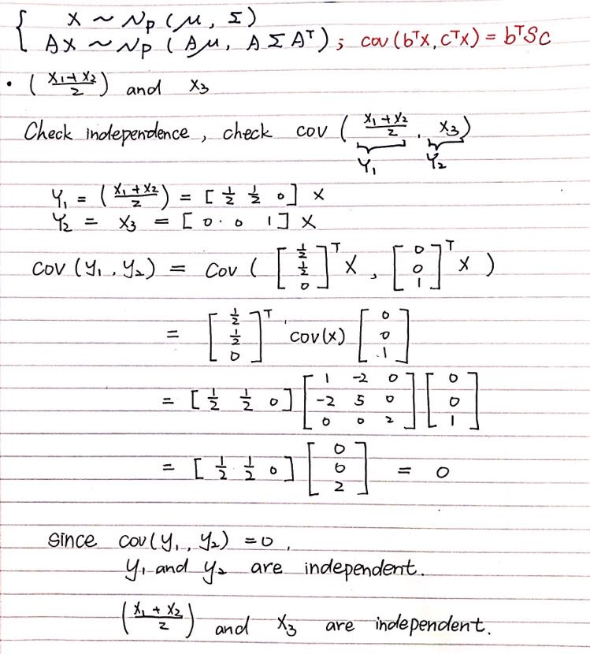

Independent

## e) x2 and (x2-5/2x1-x3)

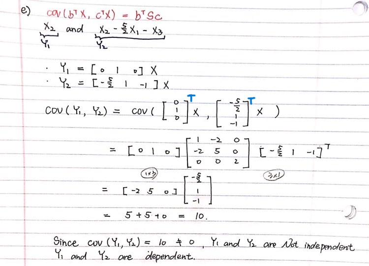

Dependent!

# Question 2 (4.4)

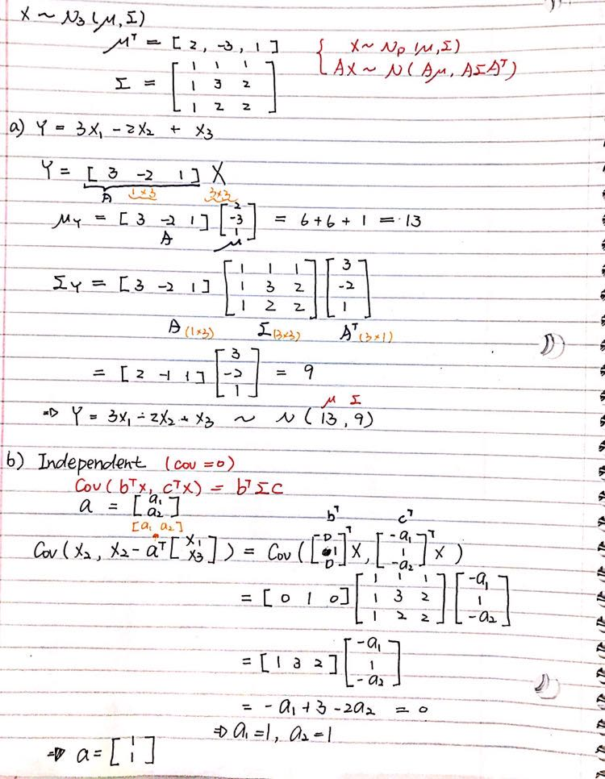

New distribution and independent

# Question 3 (4.5)

## a) X1|x2=x2

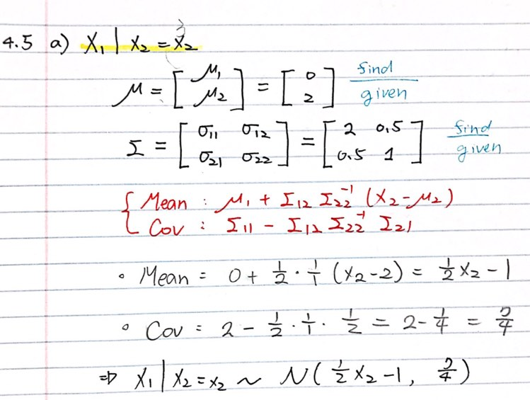

conditional distribution

## b) X2|X1=x1, X3=x3

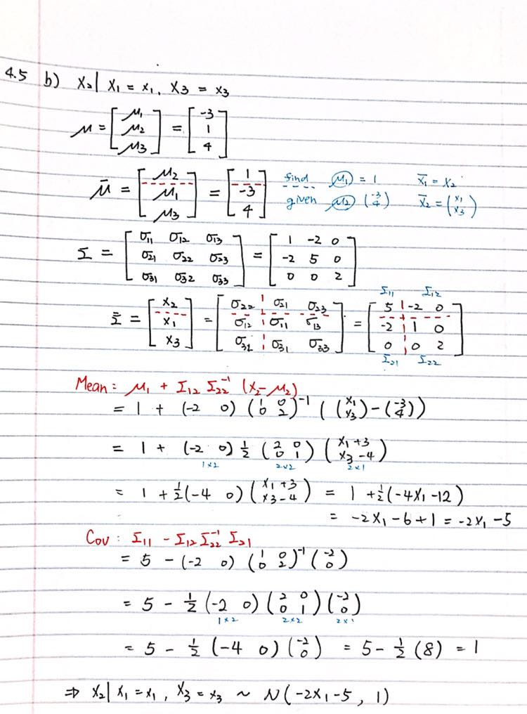

conditional distribution

## b) X3|X1=x1, X2=x2

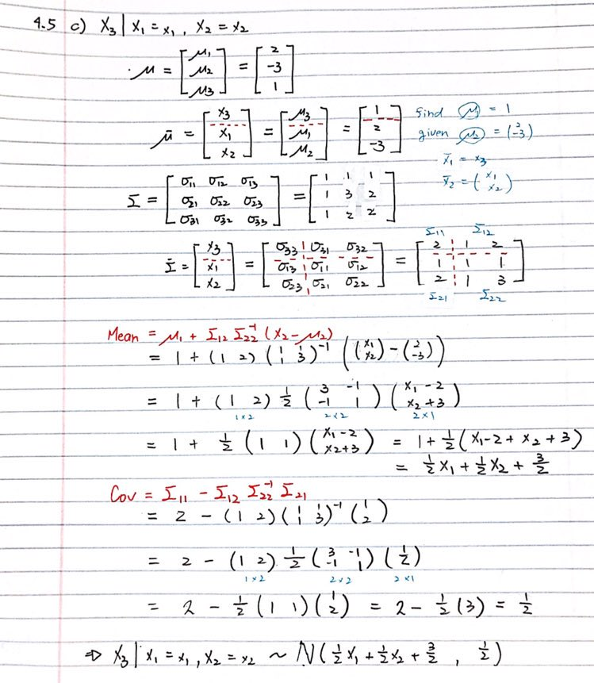

conditional distribution

# Question 4 (4.6)

$$X \tilde\ N_3(\mu, \Sigma)$$

$$\mu' = [1, -1, 2]$$

$$\Sigma = \begin{bmatrix}
\sigma_{11} & \sigma_{12} & \sigma_{13} \\
\sigma_{21} & \sigma_{22} & \sigma_{23} \\
\sigma_{31} & \sigma_{32} & \sigma_{33}
\end{bmatrix} = \begin{bmatrix}
4 & 0 & -1 \\
0 & 5 & 0 \\
-1 & 0 & 2
\end{bmatrix}$$

## a) x1 and x2

Independent! Since the covariance of x1 and x2 is 0 ($\sigma_{12} = \sigma_{21} = 0$), so x1 and x2 are independent.

## b) x1 and x3

Dependent! Since the covariance of x1 and x3 is -1, not 0 ($\sigma_{13} = \sigma_{31} = -1$), so x1 and x3 are dependent.

## c) x2 and x3

Independent! Since the covariance of x2 and x3 is 0 ($\sigma_{23} = \sigma_{32} = 0$), so x2 and x3 are independent.

## d) (x1, x3) and x2

Independent! since the covariance of (x1, x3) and x2 is 0 ($\sigma_{12} = \sigma_{21} = \sigma_{23} = \sigma_{32} = 0$), so (x1, x3) and x2 are independent

## e) x1 and (x1+3x2-2x3)

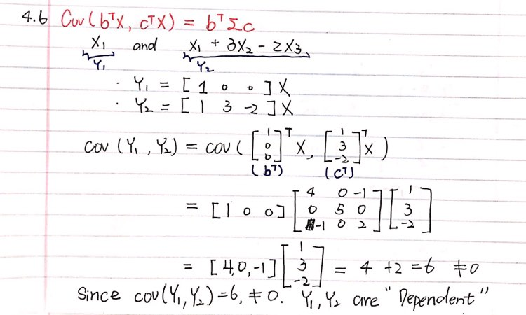

Dependent!

# Question 5 (4.7)

## a) X3=x3

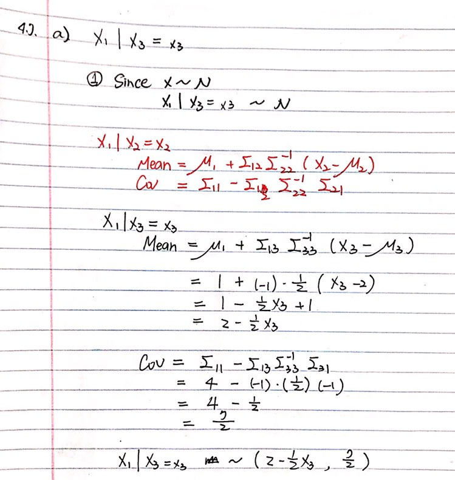

conditional distribution

## b) X2=x2, X3=x3

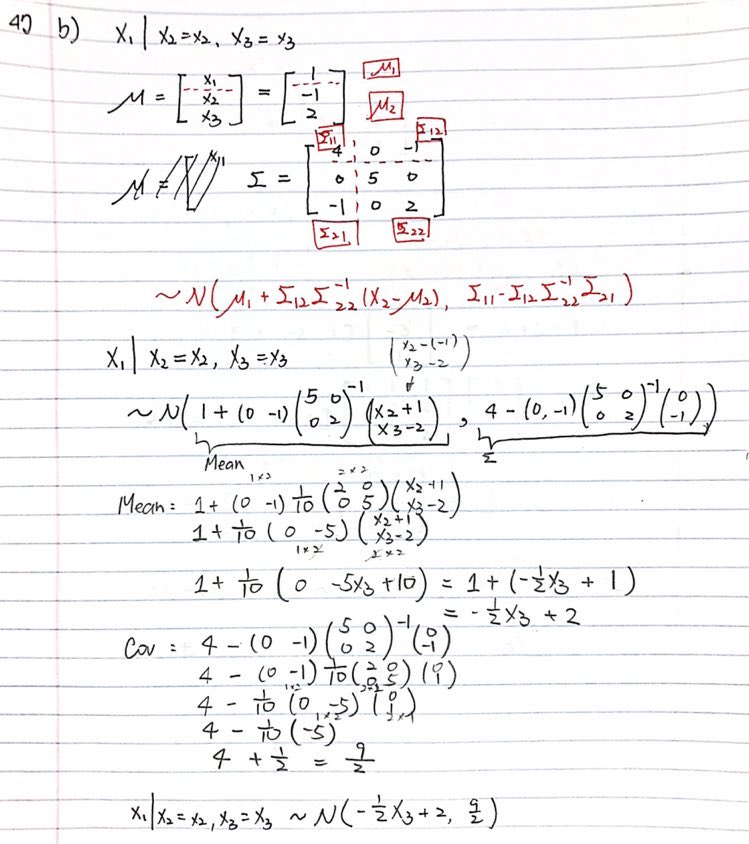

conditional distribution

# Question 6 (4.8)

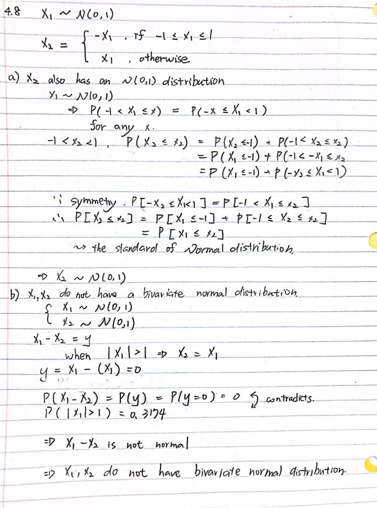

(bivariate) normal distribution

# Question 7 (4.9)

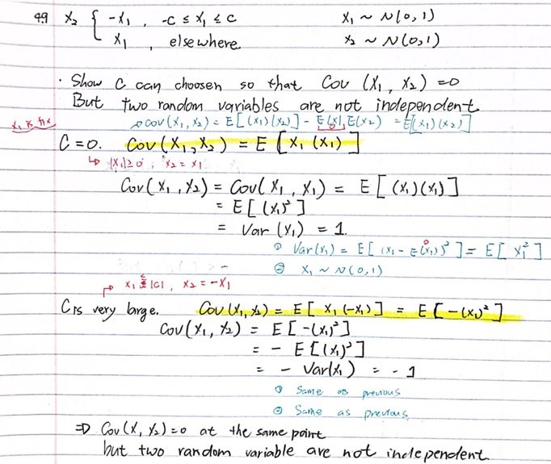

prove

# Question 8 (4.10)

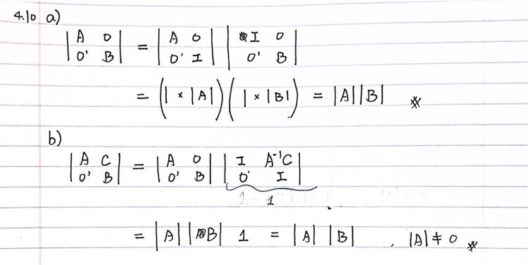

prove

# Question 9 (4.11)

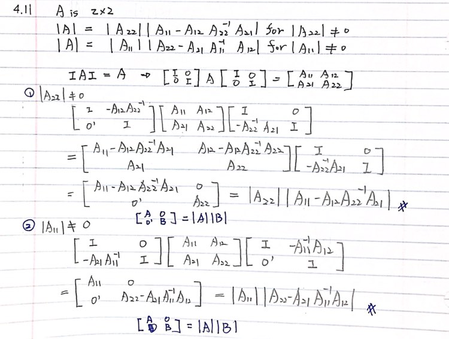

prove

# Question 10 (4.12)

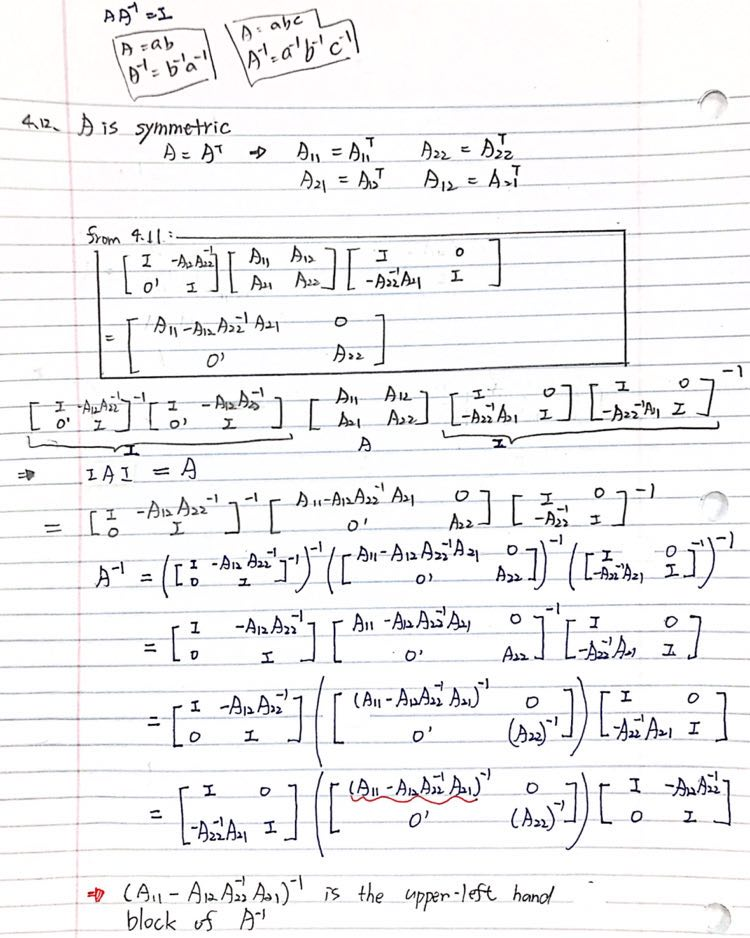

prove